# Heating, Transaction Types & Green Deal

## Analysis Prep

### Packages

```r
library(tidyverse)
```

### Load Data

Read in Leeds EPC and UK postcode data:

```r
certificates <- read.csv("~/11.2020_Project Cygnus/20.11.2020_EPC_Leeds/domestic-E08000035-Leeds/certificates.csv")
PC <- read.csv("~/11.2020_Project Cygnus/20.11.2020_EPC_Leeds/domestic-E08000035-Leeds/Postcode File/PCD_OA_LSOA_MSOA_LAD_NOV20_UK_LU.csv")
```

## Analysis: Heating Types

### Data Cleaning

#### Missing Values

```r
sum(is.na(certificates$MAINHEAT_DESCRIPTION))
```

0

There are no missing values. This is due to this being a compulsory field and potentially the use of different missing data indicators like "NODATA" or "NA". But we will get to that when we look at unique values.

#### Duplicate Observations

Remove all observations that contain duplicated building reference numbers since we only want to look at the most recent records. (It is worth noting that this may limit the outputs since the building reference number can reger to buildings or flats within them.)

```r
certificates_ord <- certificates[order(rev(certificates[, 'BUILDING_REFERENCE_NUMBER']), certificates[, 'INSPECTION_DATE']),]
certificates_dedup <- certificates_ord[!duplicated(certificates_ord$BUILDING_REFERENCE_NUMBER),]
```

#### Invalid Postcodes

Join with the postcode dataframe to remove outdated postcodes and add on LSOAs and filter out all observations that do not have the Leeds ladcd code.

```r
PC_LSOA <- PC %>%
  select(pcds, lsoa11cd, ladcd)

cert_final <- inner_join(certificates_dedup, PC_LSOA, by = c("POSTCODE" = "pcds")) %>%
  filter(ladcd == "E08000035")
```

### Unique Values

There are a lot of unique values in the Main Heating Description column. This is probably due to it combining descriptions of heating fixtures and overarching heating systems or fuels.

```r
unique(cert_final$MAINHEAT_DESCRIPTION)
```

1. Boiler and radiators, mains gas

2. Community scheme

3. Boiler and radiators, LPG

4. Electric storage heaters

5. Room heaters, electric

6. Boiler and radiators, oil

7. Electric storage heaters, radiators

8. Room heaters, mains gas

9. Boiler and underfloor heating, mains gas

10. No system present: electric heaters assumed

11. Warm air, mains gas

12. Boiler and radiators, electric

13. SAP05:Main-Heating

14. Electric underfloor heating

15. Portable electric heating assumed for most rooms, electric

16. Air source heat pump, radiators, electric

17. Portable electric heaters assumed for most rooms

18. Ground source heat pump, warm air, |Pwmp gwres sy'n tarddu yn y ddaear, awyr gynnes, |electric|trydan

19. Warm air, electric

20. Warm air, Electricaire

21. Air source heat pump, underfloor, electric

22. Air source heat pump, warm air, electric

23. Community scheme with CHP

24. Boiler and radiators, coal

25. Room heaters, radiators, electric

26. Boiler and radiators, smokeless fuel

27. Boiler and radiators, wood logs

28. Boiler and radiators, |Bwyler a rheiddiaduron, |mains gas|nwy prif gyflenwad

29. Electric ceiling heating

30. Community scheme, radiators, mains gas

31. Community scheme, mains gas

32. Boiler and radiators, dual fuel (mineral and wood)

33. Ground source heat pump, underfloor, electric

34. Room heaters, oil

35. Boiler and underfloor heating, oil

36. Room heaters, coal

37. Boiler & underfloor, mains gas

38. Portable electric heating assumed for most rooms

39. Air source heat pump, fan coil units, electric

40. Ground source heat pump, Systems with radiators, electric

41. Room heaters, dual fuel (mineral and wood)

42. Community, community

43. Portable electric heaters

44. Room heaters, smokeless fuel

45. Air source heat pump, |Pwmp gwres sy'n tarddu yn yr awyr, |, radiators, |, rheiddiaduron, |electric|trydan

46. Community scheme, underfloor, mains gas

47. Electric ceiling heating, electric

48. Boiler and radiators, wood pellets

49. Boiler and radiators, anthracite

50. Room heaters, wood logs

51. Boiler and underfloor heating, wood pellets

52. Electric Underfloor Heating (Standard tariff), electric

53. Air source heat pump , electric

54. Room heaters, |Gwresogyddion ystafell, |electric|trydan

55. Air source heat pump, Underfloor heating, pipes in screed above insulation, electric

56. Water source heat pump, radiators, electric

57. Boiler and radiators, wood chips

58. Room heaters, electricity

59. Room heaters, LPG

60. Room heaters, bottled LPG

61. Boiler and underfloor heating, LPG

62. Boiler and radiators, bottled LPG

63. Boiler and underfloor heating, |Bwyler a gwres dan y llawr, |mains gas|nwy prif gyflenwad

64. Boiler, mains gas

65. Boiler & underfloor, LPG

66. Fully double glazed, warm air, electric

67. Warm air, LPG

68. Ground source heat pump , electric

69. No system present: electric heaters assumed, mains gas

70. Boiler and underfloor heating, electric

71. Bwyler a rheiddiaduron, nwy prif gyflenwad

72. Boiler and radiators, bottled gas

73. Boiler and underfloor heating, wood logs

74. Water source heat pump, warm air, electric

75. Ground source heat pump, warm air, electric

76. Ground source heat pump, radiators, electric

77. Room heaters, anthracite

78. Boiler and radiators

79. Air source heat pump, Systems with radiators, electric

80. Air source heat pump, electric

81. Water source heat pump, underfloor, electric

82. Electric ceiling, electric

83. Boiler & underfloor, wood logs

84. Air source heat pump, radiators, mains gas

85. Ground source heat pump,warm air, electric

86. Boiler and radiators, electricity

87. Air source heat pump, Underfloor heating and radiators, pipes in screed above insulation, electric

**Levels**:**

1. 'Air source heat pump , electric'

2. 'Air source heat pump, |Pwmp gwres sy\'n tarddu yn yr awyr, |, radiators, |, rheiddiaduron, |electric|trydan'

3. 'Air source heat pump, electric'

4. 'Air source heat pump, fan coil units, electric'

5. 'Air source heat pump, radiators, electric'

6. 'Air source heat pump, radiators, mains gas'

7. 'Air source heat pump, Systems with radiators, electric'

8. 'Air source heat pump, Underfloor heating and radiators, pipes in screed above insulation, electric'

9. 'Air source heat pump, Underfloor heating, pipes in screed above insulation, electric'

10. 'Air source heat pump, underfloor, electric'

11. 'Air source heat pump, warm air, electric'

12. 'Boiler & underfloor, LPG'

13. 'Boiler & underfloor, mains gas'

14. 'Boiler & underfloor, wood logs'

15. 'Boiler and radiators'

16. 'Boiler and radiators, |Bwyler a rheiddiaduron, |mains gas|nwy prif gyflenwad'

17. 'Boiler and radiators, anthracite'

18. 'Boiler and radiators, bottled gas'

19. 'Boiler and radiators, bottled LPG'

20. 'Boiler and radiators, coal'

21. 'Boiler and radiators, dual fuel (mineral and wood)'

22. 'Boiler and radiators, electric'

23. 'Boiler and radiators, electricity'

24. 'Boiler and radiators, LPG'

25. 'Boiler and radiators, mains gas'

26. 'Boiler and radiators, oil'

27. 'Boiler and radiators, smokeless fuel'

28. 'Boiler and radiators, wood chips'

29. 'Boiler and radiators, wood logs'

30. 'Boiler and radiators, wood pellets'

31. 'Boiler and underfloor heating, |Bwyler a gwres dan y llawr, |mains gas|nwy prif gyflenwad'

32. 'Boiler and underfloor heating, electric'

33. 'Boiler and underfloor heating, LPG'

34. 'Boiler and underfloor heating, mains gas'

35. 'Boiler and underfloor heating, oil'

36. 'Boiler and underfloor heating, wood logs'

37. 'Boiler and underfloor heating, wood pellets'

38. 'Boiler, mains gas'

39. 'Bwyler a rheiddiaduron, nwy prif gyflenwad'

40. 'Community scheme'

41. 'Community scheme with CHP'

42. 'Community scheme with CHP, mains gas'

43. 'Community scheme, mains gas'

44. 'Community scheme, radiators, mains gas'

45. 'Community scheme, underfloor, mains gas'

46. 'Community, community'

47. 'Electric boiler, electric'

48. 'Electric ceiling heating'

49. 'Electric ceiling heating, electric'

50. 'Electric ceiling, electric'

51. 'Electric storage heaters'

52. 'Electric storage heaters, radiators'

53. 'Electric underfloor heating'

54. 'Electric Underfloor Heating (Standard tariff), electric'

55. 'Fully double glazed, warm air, electric'

56. 'Ground source heat pump , electric'

57. 'Ground source heat pump, radiators, electric'

58. 'Ground source heat pump, Systems with radiators, electric'

59. 'Ground source heat pump, underfloor, electric'

60. 'Ground source heat pump, warm air, |Pwmp gwres sy\'n tarddu yn y ddaear, awyr gynnes, |electric|trydan'

61. 'Ground source heat pump, warm air, electric'

62. 'Ground source heat pump,warm air, electric'

63. 'No system present: electric heaters assumed'

64. 'No system present: electric heaters assumed, mains gas'

65. 'Portable electric heaters'

66. 'Portable electric heaters assumed for most rooms'

67. 'Portable electric heating assumed for most rooms'

68. 'Portable electric heating assumed for most rooms, electric'

69. 'Room heaters, |Gwresogyddion ystafell, |electric|trydan'

70. 'Room heaters, anthracite'

71. 'Room heaters, bottled LPG'

72. 'Room heaters, coal'

73. 'Room heaters, dual fuel (mineral and wood)'

74. 'Room heaters, electric'

75. 'Room heaters, electricity'

76. 'Room heaters, LPG'

77. 'Room heaters, mains gas'

78. 'Room heaters, oil'

79. 'Room heaters, radiators, electric'

80. 'Room heaters, smokeless fuel'

81. 'Room heaters, wood logs'

82. 'Room heaters, wood pellets'

83. 'SAP05:Main-Heating'

84. 'Warm air, electric'

85. 'Warm air, Electricaire'

86. 'Warm air, LPG'

87. 'Warm air, mains gas'

88. 'Water source heat pump, radiators, electric'

89. 'Water source heat pump, underfloor, electric'

90. 'Water source heat pump, warm air, electric'

Since heating system and fuel seem to generally be after a comma, we decided to remove the strings before commas to retain only overarching heating types and fuels.

```r
cert_final$Heat_type <- sub(".*, ", "", cert_final$MAINHEAT_DESCRIPTION)
```

This left us with a more manageable amount of unique values (that also show no sign of missing value descriptions):

```r
unique(cert_final$Heat_type)
table(cert_final$Heat_type)
```

1. 'mains gas'

2. 'Community scheme'

3. 'LPG'

4. 'Electric storage heaters'

5. 'electric'

6. 'oil'

7. 'radiators'

8. 'No system present: electric heaters assumed'

9. 'SAP05:Main-Heating'

10. 'Electric underfloor heating'

11. 'Portable electric heaters assumed for most rooms'

12. '|electric|trydan'

13. 'Electricaire'

14. 'Community scheme with CHP'

15. 'coal'

16. 'smokeless fuel'

17. 'wood logs'

18. '|mains gas|nwy prif gyflenwad'

19. 'Electric ceiling heating'

20. 'dual fuel (mineral and wood)'

21. 'Portable electric heating assumed for most rooms'

22. 'community'

23. 'Portable electric heaters'

24. 'wood pellets'

25. 'anthracite'

26. 'wood chips'

27. 'electricity'

28. 'bottled LPG'

29. 'nwy prif gyflenwad'

30. 'bottled gas'

31. 'Boiler and radiators'

```
                                |electric|trydan
                                             179
                   |mains gas|nwy prif gyflenwad
                                              56
                                      anthracite
                                              11
                            Boiler and radiators
                                               4
                                     bottled gas
                                               3
                                     bottled LPG
                                               5
                                            coal
                                              96
                                       community
                                              19
                                Community scheme
                                            4177
                       Community scheme with CHP
                                              34
                    dual fuel (mineral and wood)
                                              94
                                        electric
                                           21279
                        Electric ceiling heating
                                              43
                        Electric storage heaters
                                           12531
                     Electric underfloor heating
                                             979
                                    Electricaire
                                             348
                                     electricity
                                               3
                                             LPG
                                             399
                                       mains gas
                                          179520
     No system present: electric heaters assumed
                                            1165
                              nwy prif gyflenwad
                                               3
                                             oil
                                             373
                       Portable electric heaters
                                               8
Portable electric heaters assumed for most rooms
                                             746
Portable electric heating assumed for most rooms
                                             108
                                       radiators
                                             743
                              SAP05:Main-Heating
                                             384
                                  smokeless fuel
                                              55
                                      wood chips
                                               2
                                       wood logs
                                              33
                                    wood pellets
                                              16
```

Still, some values seem to only show heating fixtures (e.g. radiators), which is caused by them not containing any additional information.

### Grouping Unique Values

Create a dataframe that only contains relevant columns:

```r
Heating <- cert_final %>% select(HEATING_COST_CURRENT, HEATING_COST_POTENTIAL, MAINHEAT_DESCRIPTION, Heat_type, lsoa11cd)
```

Create an extra column to rename unique values according to reasonable subgroups. We chose to leave some unique values that only hinted at the fuel type (e.g. Electric Storage Heaters) in their own groups. We did this to give an unbiased overview of what EPC data offers.

```r
Heating2 <- Heating %>%
  mutate(
    Gen_Heat = case_when(
      Heat_type == "bottled gas" ~ "Bottled Gas",
      Heat_type == "bottled LPG" ~ "Bottled LPG",
      Heat_type == "LPG" ~ "LPG",
      Heat_type == "mains gas" ~ "Mains Gas",
      Heat_type == "|mains gas|nwy prif gyflenwad" ~ "Mains Gas",
      Heat_type == "nwy prif gyflenwad" ~ "Mains Gas",
      Heat_type == "anthracite" ~ "Coal and Anthracite",
      Heat_type == "coal" ~ "Coal and Anthracite",
      Heat_type == "anthracite" ~ "Coal and Anthracite",
      Heat_type == "dual fuel (mineral and wood)" ~ "Dual Fuel (Mineral and Wood)",
      Heat_type == "wood chips" ~ "Wood",
      Heat_type == "wood logs" ~ "Wood",
      Heat_type == "wood pellets" ~ "Wood",
      Heat_type == "community" ~ "Community Scheme",
      Heat_type == "Community scheme" ~ "Community Scheme",
      Heat_type == "Community scheme with CHP" ~ "Community Scheme with CHP",
      Heat_type == "electric" ~ "Electric",
      Heat_type == "|electric|trydan" ~ "Electric",
      Heat_type == "Electricaire" ~ "Electric",
      Heat_type == "electricity" ~ "Electric",
      Heat_type == "Electric ceiling heating" ~ "Electric Ceiling Heating",
      Heat_type == "Electric storage heaters" ~ "Electric Storage Heating",
      MAINHEAT_DESCRIPTION == "Electric storage heaters, radiators" ~ "Electric Storage Heating & Radiators",
      Heat_type == "Electric underfloor heating" ~ "Electric Underfloor Heating",
      Heat_type == "Portable electric heaters" ~ "Portable Electric Heating",
      Heat_type == "Portable electric heaters assumed for most rooms" ~ "Portable Electric Heating",
      Heat_type == "Portable electric heating assumed for most rooms" ~ "Portable Electric Heating",
      Heat_type == "No system present: electric heaters assumed" ~ "No system present: Electric heaters assumed",
      Heat_type == "oil" ~ "Oil",
      Heat_type == "smokeless fuel" ~ "Smokeless Fuel",
      Heat_type == "Boiler and radiators" ~ "Unknown",
      Heat_type == "SAP05:Main-Heating" ~ "Unknown"
    )
  )
```

### Tables

We created two tables one containing the frequencies of the Heating Types for visualisation, and Heating Types by LSOAs for the Data Mapper.

```r
Heat_Freq <- data.frame(table(Heating2$Gen_Heat))
write.csv(Heat_Freq, 'HeatingTypes_Frequencies.csv')

Heat_LSOA <- xtabs(~ lsoa11cd + Gen_Heat, data=Heating2)
write.csv(Heat_LSOA, 'HeatingType_LSOA.csv')
```

### Visualisation

Create a bar chart for the Heating Types:

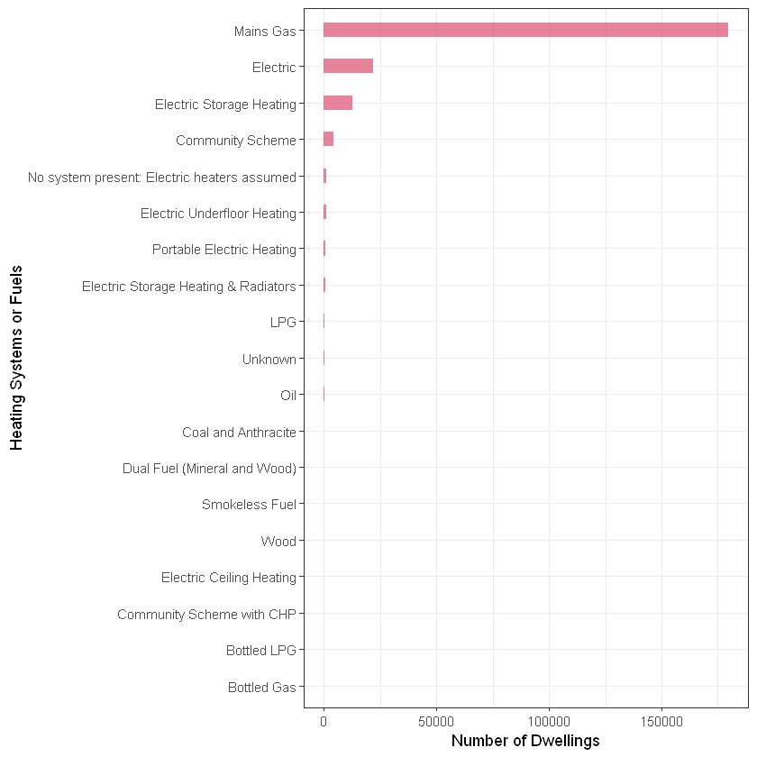

```r
Heat_Freq %>%
  mutate(Var1 = fct_reorder(Var1, Freq)) %>%
  ggplot( aes(x=Var1, y=Freq)) +
  geom_bar(stat="identity", fill="#D73058", alpha=.6, width=.4) +
  xlab("Heating Systems or Fuels") +
  ylab("Number of Dwellings") +
  theme_bw() +
  coord_flip()
```

This approach results in a somewhat unhelpful graph. However, it shows how much need there is to standardise in the EPC creation process.

### Extra: Grouping according to ONS report

The ONS report on the EPC data also contains a visualisation of Heating Systems and Fuel distribution. They chose to heavily summarise the groupings by only using "Mains Gas", "Electric", "Community Scheme", "Oil", "Other" and "Unknown".

#### Grouping

We grouped smaller subgroups as 'Other' and made the assumption that observations that showed only electrical fixtures could be grouped into 'Electric'.

```r
HeatingONS <- Heating %>%
  mutate(
    Gen_Heat = case_when(
      Heat_type == "bottled gas" ~ "Other",
      Heat_type == "bottled LPG" ~ "Other",
      Heat_type == "LPG" ~ "Other",
      Heat_type == "mains gas" ~ "Mains Gas",
      Heat_type == "|mains gas|nwy prif gyflenwad" ~ "Mains Gas",
      Heat_type == "nwy prif gyflenwad" ~ "Mains Gas",
      Heat_type == "anthracite" ~ "Other",
      Heat_type == "coal" ~ "Other",
      Heat_type == "anthracite" ~ "Other",
      Heat_type == "dual fuel (mineral and wood)" ~ "Other",
      Heat_type == "wood chips" ~ "Other",
      Heat_type == "wood logs" ~ "Other",
      Heat_type == "wood pellets" ~ "Other",
      Heat_type == "community" ~ "Community Scheme",
      Heat_type == "Community scheme" ~ "Community Scheme",
      Heat_type == "Community scheme with CHP" ~ "Community Scheme",
      Heat_type == "electric" ~ "Electric",
      Heat_type == "|electric|trydan" ~ "Electric",
      Heat_type == "Electricaire" ~ "Electric",
      Heat_type == "electricity" ~ "Electric",
      Heat_type == "Electric ceiling heating" ~ "Electric",
      Heat_type == "Electric storage heaters" ~ "Electric",
      MAINHEAT_DESCRIPTION == "Electric storage heaters, radiators" ~ "Electric",
      Heat_type == "Electric underfloor heating" ~ "Electric",
      Heat_type == "Portable electric heaters" ~ "Electric",
      Heat_type == "Portable electric heaters assumed for most rooms" ~ "Electric",
      Heat_type == "Portable electric heating assumed for most rooms" ~ "Electric",
      Heat_type == "No system present: electric heaters assumed" ~ "Unknown",
      Heat_type == "oil" ~ "Oil",
      Heat_type == "smokeless fuel" ~ "Other",
      Heat_type == "Boiler and radiators" ~ "Unknown",
      Heat_type == "SAP05:Main-Heating" ~ "Unknown"
    )
  )
```

#### Tables

We, again, created two tables one containing the frequencies of the Heating Types for visualisation, and Heating Types by LSOAs for the Data Mapper.

```r
Heat_FreqONS <- data.frame(table(HeatingONS$Gen_Heat))
write.csv(Heat_Freq, 'HeatingTypesONS_Frequencies.csv')

Heat_LSOAONS <- xtabs(~ lsoa11cd + Gen_Heat, data=HeatingONS)
write.csv(Heat_LSOA, 'HeatingType_LSOA.csv')
```

#### Visualisation

Create a bar chart for the Heating Types:

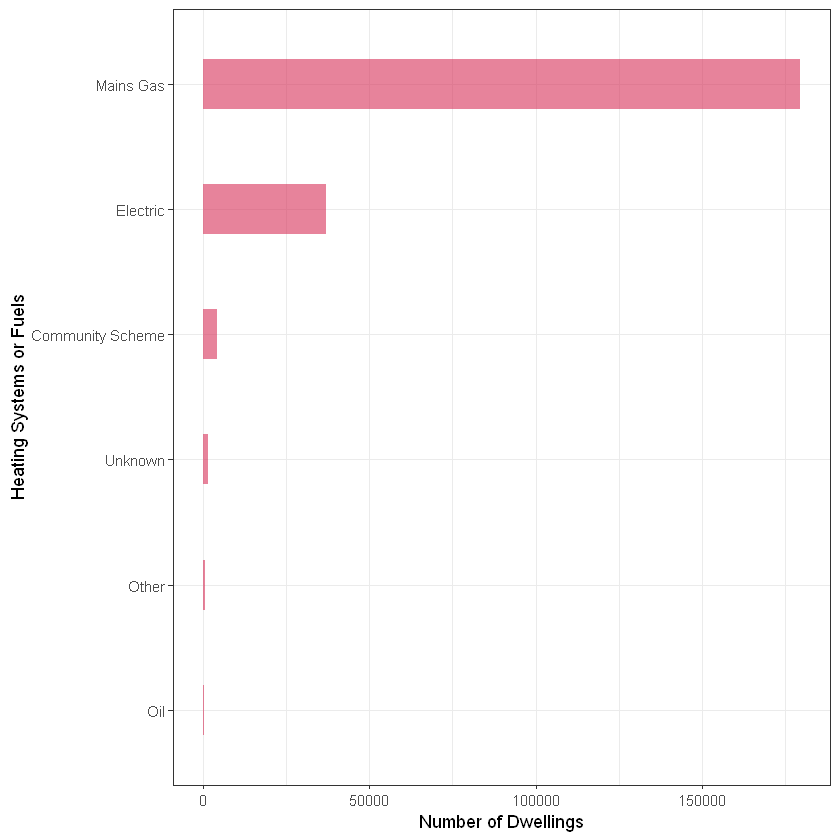

```r
Heat_FreqONS %>%
  mutate(Var1 = fct_reorder(Var1, Freq)) %>%
  ggplot( aes(x=Var1, y=Freq)) +
  geom_bar(stat="identity", fill="#D73058", alpha=.6, width=.4) +
  xlab("Heating Systems or Fuels") +
  ylab("Number of Dwellings") +
  theme_bw() +
  coord_flip()
```

This creates a much more less cluttered visual of the Heating Systems and Fuels that are being used in Leeds. However, this also heavily simplifies the groupings, which may bias potential further analysis into heating cost differences.

## Analysis: Transaction Types

### Data Cleaning

This uses the cleaned dataframe 'cert_final' from the Heating Types - Data Cleaning Section.

#### Missing Values

```r
sum(is.na(cert_final$TRANSACTION_TYPE))
```

0

Again there are no missing values.

#### Unique Values

```r
unique(cert_final$TRANSACTION_TYPE)
table (cert_final$TRANSACTION_TYPE)
```

1. marketed sale

2. ECO assessment

3. rental (private)

4. none of the above

5. non marketed sale

6. new dwelling

7. rental (social)

8. assessment for green deal

9. FiT application

10. rental

11. not recorded

12. RHI application

13. following green deal

14. Stock Condition Survey

15. unknown

16. rental (private) - this is for backwards compatibility only and should not be used

**Levels**:**

1. 'assessment for green deal'

2. 'ECO assessment'

3. 'FiT application'

4. 'following green deal'

5. 'marketed sale'

6. 'new dwelling'

7. 'non marketed sale'

8. 'none of the above'

9. 'not recorded'

10. 'rental'

11. 'rental (private)'

12. 'rental (private) - this is for backwards compatibility only and should not be used'

13. 'rental (social)'

14. 'RHI application'

15. 'Stock Condition Survey'

16. 'unknown'

```
                                                         assessment for green deal
                                                                              6876
                                                                    ECO assessment
                                                                              8404
                                                                   FiT application
                                                                              2634
                                                              following green deal
                                                                               297
                                                                     marketed sale
                                                                             80455
                                                                      new dwelling
                                                                             20807
                                                                 non marketed sale
                                                                              4866
                                                                 none of the above
                                                                             15365
                                                                      not recorded
                                                                                 7
                                                                            rental
                                                                              1667
                                                                  rental (private)
                                                                             42630
rental (private) - this is for backwards compatibility only and should not be used
                                                                                13
                                                                   rental (social)
                                                                             39153
                                                                   RHI application
                                                                               115
                                                            Stock Condition Survey
                                                                                10
                                                                           unknown
                                                                               117
```

A look into the unique values of this column shows that it is more standardised and missing entries are summarised as "unknown".

### Grouping Unique Values

There are a few variables that clutter the data. This means that the long and unuseful private rental variable is being removed. Then "not recorded" cases are renamed to "unknown". "None of the above", is not grouped into "unknown" since it does not necessarily mean this data is unavailable.

```r
Transaction <- cert_final %>%
  select(lsoa11cd, TRANSACTION_TYPE)
Transaction$TRANSACTION_TYPE <- gsub('not recorded', 'unknown', Transaction$TRANSACTION_TYPE)
Transaction <- Transaction[!(Transaction$TRANSACTION_TYPE=="rental (private) - this is for backwards compatibility only and should not be used"),]

unique(Transaction$TRANSACTION_TYPE)
```

1. 'marketed sale'

2. 'ECO assessment'

3. 'rental (private)'

4. 'none of the above'

5. 'non marketed sale'

6. 'new dwelling'

7. 'rental (social)'

8. 'assessment for green deal'

9. 'FiT application'

10. 'rental'

11. 'unknown'

12. 'RHI application'

13. 'following green deal'

14. 'Stock Condition Survey'

### Tables

```r
TransDf <- data.frame(table(Transaction$TRANSACTION_TYPE))
write.csv(TransDf, 'TransactionType_Frequencies.csv')

TransDf1 <- xtabs(~ lsoa11cd + TRANSACTION_TYPE, data=Transaction)
write.csv(TransDf1, 'TransactionType_LSOA.csv')
```

### Visualisation

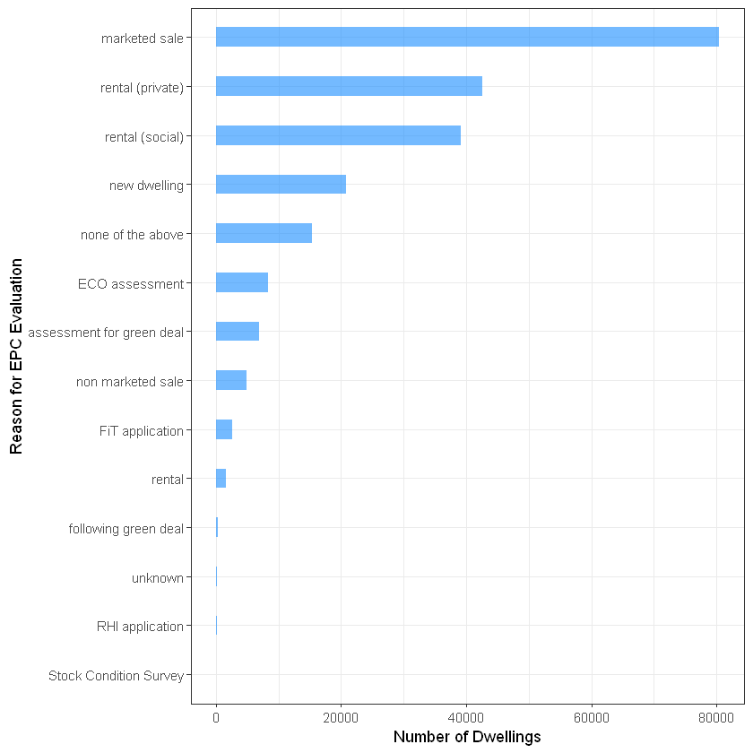

```r
TransDf %>%
  mutate(Var1 = fct_reorder(Var1, Freq)) %>%
  ggplot( aes(x=Var1, y=Freq)) +
  geom_bar(stat="identity", fill="#178CFF", alpha=.6, width=.4) +
    xlab("Reason for EPC Evaluation") +
    ylab("Number of Dwellings") +
    theme_bw() +
    coord_flip()
```

### Extra: Analysis for all observations (so including duplicates)

We can also look at all reasons for EPC inspections in Leeds rather than just the most recent ones.

#### Cleaning

For this, we only clean out invalid postcodes, create a table with only relevant columns, and rename and group variables as before.

```r
cert_ALL <- inner_join(certificates, PC_LSOA, by = c("POSTCODE" = "pcds")) %>%
  filter(ladcd == "E08000035")

Transaction_ALL <- cert_ALL %>%
  select(lsoa11cd, TRANSACTION_TYPE)
Transaction_ALL$TRANSACTION_TYPE <- gsub('not recorded', 'unknown', Transaction_ALL$TRANSACTION_TYPE)
Transaction_ALL <- Transaction_ALL[!(Transaction_ALL$TRANSACTION_TYPE=="rental (private) - this is for backwards compatibility only and should not be used"),]
```

#### Tables

```r
TransDf_ALL <- data.frame(table(Transaction_ALL$TRANSACTION_TYPE))
write.csv(TransDf_ALL, 'ALLTransactionType_Frequencies.csv')

TransDf1_ALL <- xtabs(~ lsoa11cd + TRANSACTION_TYPE, data=Transaction_ALL)
write.csv(TransDf1_ALL, 'ALLTransactionType_LSOA.csv')
```

#### Visualisation

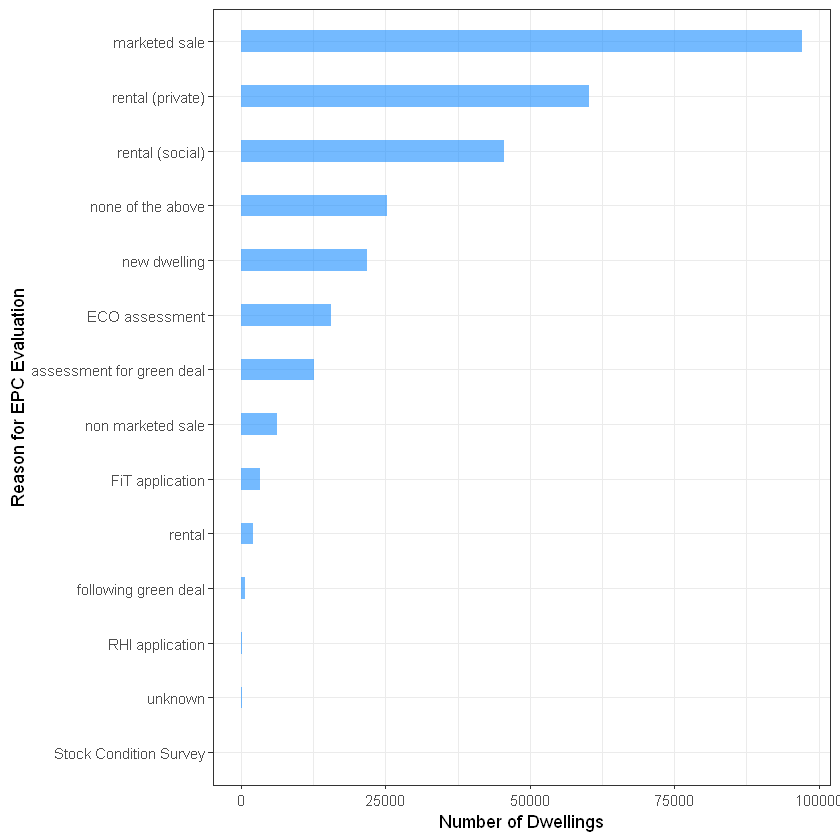

```r
TransDf_ALL %>%
  mutate(Var1 = fct_reorder(Var1, Freq)) %>%
  ggplot( aes(x=Var1, y=Freq)) +
  geom_bar(stat="identity", fill="#178CFF", alpha=.6, width=.4) +
    xlab("Reason for EPC Evaluation") +
    ylab("Number of Dwellings") +
    theme_bw() +
    coord_flip()
```

## Green Deal

We decided to take a more detailed look at the results of the Green Deal (GD) scheme. This is relatively well reflected in the EPC data, since the Transaction Types include "Assessment for Green Deal" and "Following Green Deal".

### Data Cleaning

This time, we do not work with the previously cleaned cert_final data frame, since we want to keep duplicates and invalid postcodes. This is because we want to compare te effect of GD initiatives on the same properties. Since assessment for the GD may be a bit older and may contain invalid postcodes, we keep these to avoid losing observations.

First, we drop every observation that does not contain GD in its Transaction Type.

```r
GreenDeal <- certificates_ord %>%
  filter(str_detect(TRANSACTION_TYPE, "green deal"))
```

We keep only duplicated building reference numbers since we want to compare before and after for the same building reference numbers.

```r
GreenDeal <- GreenDeal[GreenDeal$BUILDING_REFERENCE_NUMBER %in% GreenDeal$BUILDING_REFERENCE_NUMBER[duplicated(GreenDeal$BUILDING_REFERENCE_NUMBER)],] %>%
    select(BUILDING_REFERENCE_NUMBER, TRANSACTION_TYPE, INSPECTION_DATE, CURRENT_ENERGY_EFFICIENCY, POTENTIAL_ENERGY_EFFICIENCY)
GreenDeal$INSPECTION_DATE <- as.numeric(GreenDeal$INSPECTION_DATE)
```

We then remove older doubles for the observations classed as "assessment for GD" and newer doubles of those classed as "following GD". We do this to compare the state of properties, as closely surrounding the implementation of GD measures as possible. This is done by creating two separate dataframes.

```r
# Assessment for Green Deal:

GD_assmt <- GreenDeal %>%
  filter(TRANSACTION_TYPE == "assessment for green deal") %>%
  arrange(., BUILDING_REFERENCE_NUMBER, desc(INSPECTION_DATE))
GD_assmt <- GD_assmt[!duplicated(GD_assmt$BUILDING_REFERENCE_NUMBER),]

# Create a Column for the difference between Potential and Current Energy Efficiency
GD_assmt$Diff_EE <- (GD_assmt$POTENTIAL_ENERGY_EFFICIENCY - GD_assmt$CURRENT_ENERGY_EFFICIENCY)

# Add an indicator to the column names to help differentiate the dataframes
colnames(GD_assmt) <- paste("A", colnames(GD_assmt), sep = "_")
```

```r
# Following Green Deal:

GD_follw <- GreenDeal %>%
  filter(TRANSACTION_TYPE == "following green deal") %>%
  arrange(., BUILDING_REFERENCE_NUMBER, INSPECTION_DATE)
GD_follw <- GD_follw[!duplicated(GD_follw$BUILDING_REFERENCE_NUMBER),]

# Create a Column for the difference between Potential and Current Energy Efficiency
GD_follw$Diff_EE <- (GD_follw$POTENTIAL_ENERGY_EFFICIENCY - GD_follw$CURRENT_ENERGY_EFFICIENCY)

# Add an indicator to the column names to help differentiate the dataframes
colnames(GD_follw) <- paste("F", colnames(GD_follw), sep = "_")
```

The two dataframes created in the last step are then joined to compare them directly:

```r
GD_comp <- inner_join(GD_assmt, GD_follw, by = c("A_BUILDING_REFERENCE_NUMBER" = "F_BUILDING_REFERENCE_NUMBER"))
```

Interestingly, there are some building reference numbers where inspection dates for GD assessments are later than inspections classed as "following GD". This may indicate that there may have been several GDs in these properties, suggesting that cleaning out duplicates in the last step may have caused these inconsistencies. This may be looked into in further analyses. However, for now these observations will be dropped, since the assessment date for the GD should reasonably not be after the GD has been implemented.

```r
GD_comp2 <- GD_comp %>%
    filter(., A_INSPECTION_DATE < F_INSPECTION_DATE)
```

### Calculating Difference Variables

In this step the differences between the different levels of Energy Efficiency are calculated, to enable the illustration of changes.

#### Changes in 'Current Energy Efficiency' before and after Green Deal

```r
GD_comp2$Diff_CEE <- (GD_comp2$F_CURRENT_ENERGY_EFFICIENCY - GD_comp2$A_CURRENT_ENERGY_EFFICIENCY)
```

#### Difference between 'Potential Energy Efficiency' before Green Deal and 'Current Energy Efficiency' after

```r
GD_comp2$Diff_AP_FC <- (GD_comp2$F_CURRENT_ENERGY_EFFICIENCY - GD_comp2$A_POTENTIAL_ENERGY_EFFICIENCY)
```

#### Difference between Past and Present: Current and Potential Divide

```r
GD_comp2$Diff_ADE_FDE <- (GD_comp2$F_Diff_EE - GD_comp2$A_Diff_EE)
```

### Means of Difference Variables

#### 'Current Energy Efficiency' before and after Green Deal:

```r
mean (GD_comp2 [["Diff_CEE"]])
```

11.1040816326531

This means that Energy Efficiency on average improved by roughly 1 band upon the implementation of GD measures.

#### 'Potential Energy Efficiency' before Green Deal and 'Current Energy Efficiency' after:

```r
mean (GD_comp2 [["Diff_AP_FC"]])
```

-11.7979591836735

This shows that the Energy Efficiency following the implementation of GD measures was generally 1 band under the proposed potential prior to GD measures.

#### 'Potential Energy Efficiency' and 'Current Energy Efficiency' before Green Deal:

```r
mean (-(GD_comp2 [["A_Diff_EE"]]))
# negative to make it comparable
```

-22.9020408163265

The Energy Efficiency before the implementation of GD measures was on average 2 bands lower than its respective potential. Combined with the previous average, this means that the gap between Energy Efficiency and the old potential has aproximately halved.

#### Past and Present: Current-Potential Divide:

```r
mean (GD_comp2 [["Diff_ADE_FDE"]])
```

-7.15102040816326

This comparison may not be too necessary but it shows that the difference between current and potential Energy Efficiency after GD implementation is generally lower than before it.

### Table

```r
write.csv(GD_comp2, 'Green_Deal_Comparisons.csv')
```

### Visualisation of Differences

#### 'Current Energy Efficiency' before and after Green Deal:

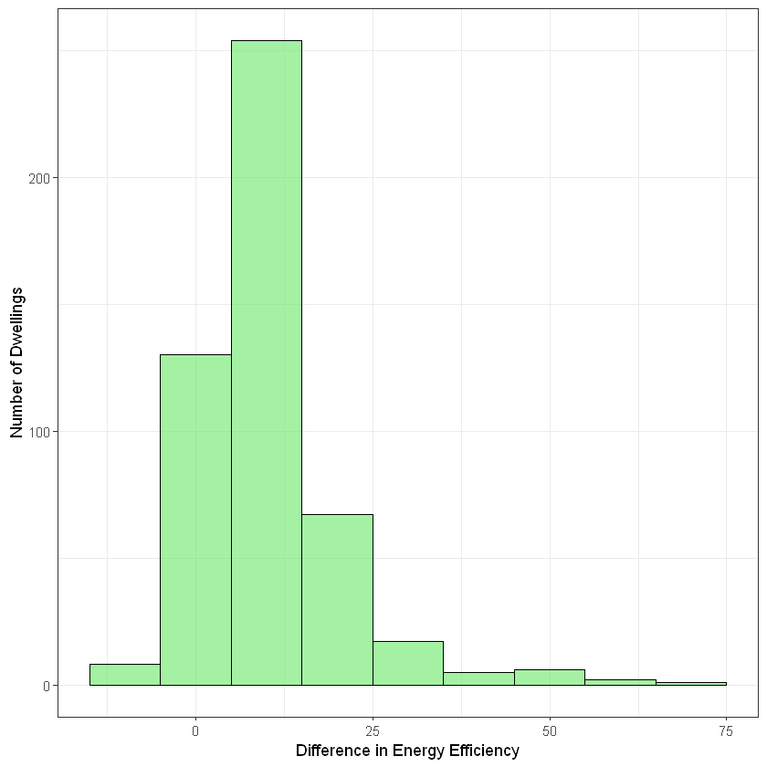

```r
ggplot(GD_comp2, aes(x=Diff_CEE)) +
  geom_histogram(color= "black", fill="#67E767", alpha=.6, binwidth=10) +
    xlab("Difference in Energy Efficiency") +
    ylab("Number of Dwellings") +
    theme_bw()
```

This graph shows that the Energy Efficiency of dwellings following GD implementation is mostly larger than before. There are some cases at the upper end of the spectrum where the Energy Efficiency has improved greatly, but there are also a few cases where Energy Efficiency has decreased. These outliers should be further explored to identify underlying reasons or if they are errors.

#### 'Potential Energy Efficiency' before Green Deal and 'Current Energy Efficiency' after:

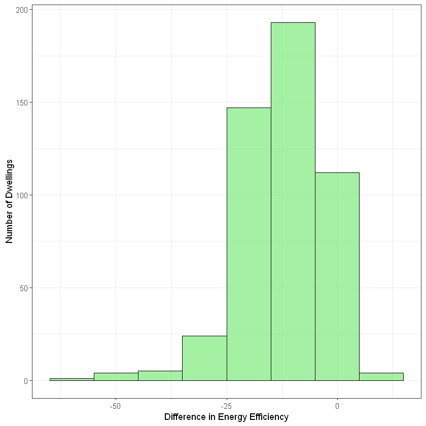

```r
ggplot(GD_comp2, aes(x=Diff_AP_FC)) +
  geom_histogram(color= "black", fill="#67E767", alpha=.6, binwidth=10) +
  xlab("Difference in Energy Efficiency") +
  ylab("Number of Dwellings") +
  theme_bw()
```

This visualisation shows that the Energy Efficiency dwellings have achieved through the GD was sometimes on target for the potential proposed prior to GD implementation but generally just under. Some dwellings have even surpassed previous potentials following GD measures.

#### 'Potential Energy Efficiency' and 'Current Energy Efficiency' before Green Deal:

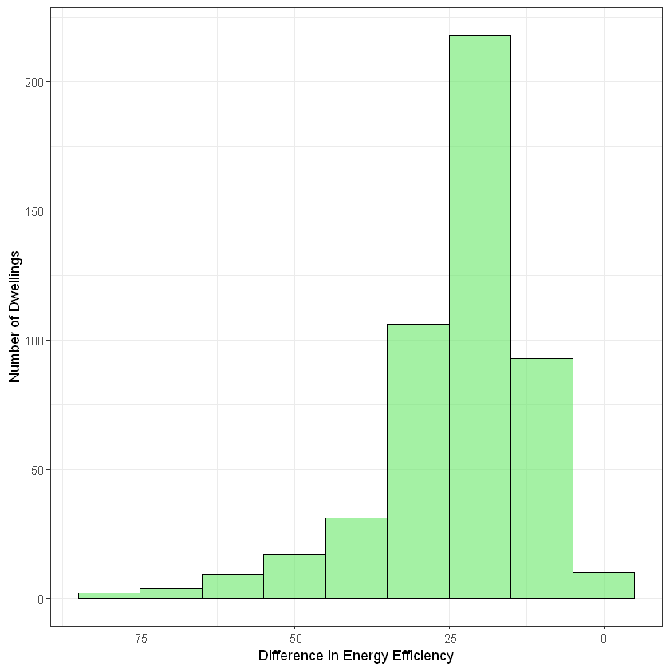

```r
ggplot(GD_comp2, aes(x=-(A_Diff_EE))) +
  geom_histogram(color= "black", fill="#67E767", alpha=.6, binwidth=10) +
  xlab("Difference in Energy Efficiency") +
  ylab("Number of Dwellings") +
  theme_bw()
```

This chart offers a good point of comparison for the previous one. It shows that the gap between the current energy efficiency preceding GD measures and the respective potential was generally bigger than following GD implementation. It may be interesting to look into changes in Energy Efficiency for individual dwellings, especially at the lower end of the spectrum to test the magnitude of changes and improvements.

#### Past and Present: Current and Potential Divide:

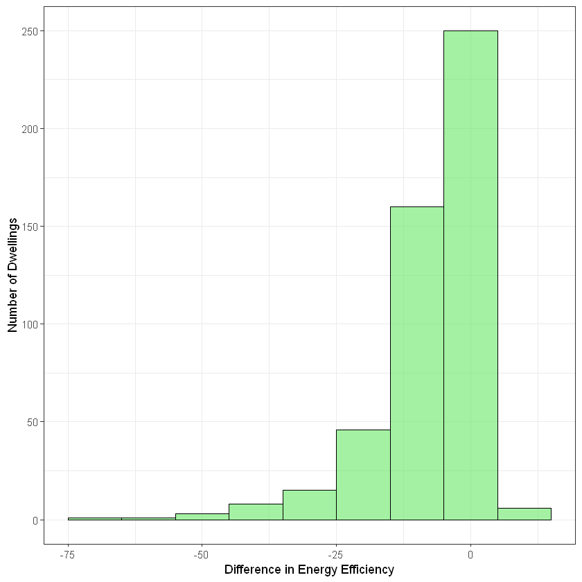

```r
ggplot(GD_comp2, aes(x=Diff_ADE_FDE)) +
  geom_histogram(color= "black", fill="#67E767", alpha=.6, binwidth=10) +
  xlab("Difference in Energy Efficiency") +
  ylab("Number of Dwellings") +
  theme_bw()
```

This final graph visualises the difference between the current-potential gaps in Energy Efficiency before and after GD implementation. It shows that the proposed potentials after dwellings have taken advantage of GD measures are often similarly distant to their respective current Energy Efficiency values, as the before GD implementation. However, the current-potential gap is generally smaller following the GD than before it.